# Single-cell RNAseq Workshop

# Finding marker genes

## What makes a good marker?

- **Specific**: high in the cluster, low everywhere else
- **Detected**: expressed in a good fraction of the cluster’s cells
- **Useful**: interpretable, ideally a gene with known biology

## `FindMarkers`: one cluster against all other cells

```r
# cluster 1 vs all other cells when ident.2 is not specified
cluster1.markers <- FindMarkers(seu, ident.1 = 1)

cluster1.markers$gene <- rownames(cluster1.markers)
head(cluster1.markers, n = 15)
```

## How to read the table

- `avg_log2FC`: positive when higher in the cluster, negative when higher in the rest
- `pct.1` and `pct.2`: fraction of cells expressing the gene in each group
  - a good marker is high in `pct.1` and low in `pct.2`
- `p_val_adj`: **over-optimistic**
  - the clusters were defined from the same data we now test
  - use it to rank genes, not as a literal significance level

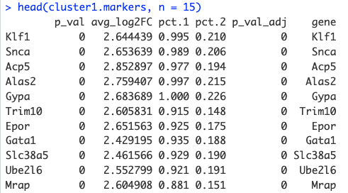

## Positive and negative markers

**Positive**: higher in the cluster

```r
positive.markers <- cluster1.markers %>%
  filter(avg_log2FC > 0) %>%
  arrange(desc(avg_log2FC))
head(positive.markers, 10)
```

**Negative**: higher in all other cells

```r
negative.markers <- cluster1.markers %>%
  filter(avg_log2FC < 0) %>%
  arrange(avg_log2FC)
head(negative.markers, 10)
```

## `FindAllMarkers`: positive markers for every cluster

```r
all.markers <- FindAllMarkers(seu,
                              only.pos = TRUE,
                              min.pct = 0.05,
                              logfc.threshold = 0.25, # pct expressed in either of the two populations
                              return.thresh = 0.05,   # p-value threshold
                              verbose = TRUE)

# fraction of cells expressing the gene: inside minus outside the cluster
all.markers <- all.markers |>
  mutate(pct_difference = pct.1 - pct.2)
```

## Top markers per cluster

```r
top5 <- all.markers %>%
  filter(p_val_adj < 0.05) %>%
  group_by(cluster) %>%
  slice_max(pct_difference, n = 5, with_ties = FALSE)

top10 <- all.markers %>%
  filter(p_val_adj < 0.05) %>%
  group_by(cluster) %>%
  slice_max(pct_difference, n = 10, with_ties = FALSE)

print(top5, n = 20)
```

- We rank by `pct_difference`: how much more often the gene is detected inside the cluster than outside

## Save the tables

```r
dir.create("res", showWarnings = FALSE)

write.csv(cluster1.markers, "res/cluster1_markers.csv", quote = FALSE, row.names = FALSE)
write.csv(all.markers,      "res/all_markers.csv",      quote = FALSE, row.names = FALSE)
write.csv(top5,             "res/top5_markers.csv",     quote = FALSE, row.names = FALSE)
write.csv(top10,            "res/top10_markers.csv",    quote = FALSE, row.names = FALSE)
```

# Visualizing markers

## Pick two genes from cluster 1

```r
genes <- top5$gene[top5$cluster == 1][1:2]
genes
```

## Ridge, violin, and feature plots

```r
# ridge plot (needs the ggridges package)
RidgePlot(seu, features = genes, ncol = 2)

# violin plot
VlnPlot(seu, features = genes, pt.size = 0, ncol = 2)

# feature plot on the UMAP (the default reduction)
FeaturePlot(seu, features = genes, reduction = "umap", ncol = 2)
```

## What does each plot show that the others don’t?

- Ridge and violin plots show the **distribution per cluster**
  - is expression bimodal or unimodal?
- The feature plot shows **where on the embedding** the gene is
  - does it mark one region or several?

## A heatmap on a reduced number of cells

```r
seu_small <- subset(seu, downsample = 100)    # up to 100 cells per cluster
feats <- unique(top5$gene)                    # use top10$gene for more genes
seu_small <- ScaleData(seu_small, features = feats)   # DoHeatmap needs scaled data

DoHeatmap(seu_small, features = feats,
          size = 4) +                                 # cluster labels on top
  theme(axis.text.y = element_text(size = 5.5)) +     # gene names
  guides(colour = "none")                             # hide group legend, keep color bar
```

## Reading the heatmap

- Colors are **z-scores**: each gene is centered on its own average
  - magenta: below the gene’s average
  - black: near the average
  - yellow: above the average
- Colors are relative within a gene
  - brightness cannot be compared between genes
- Downsampling stops large clusters from dominating the plot

## Heatmap of the top markers

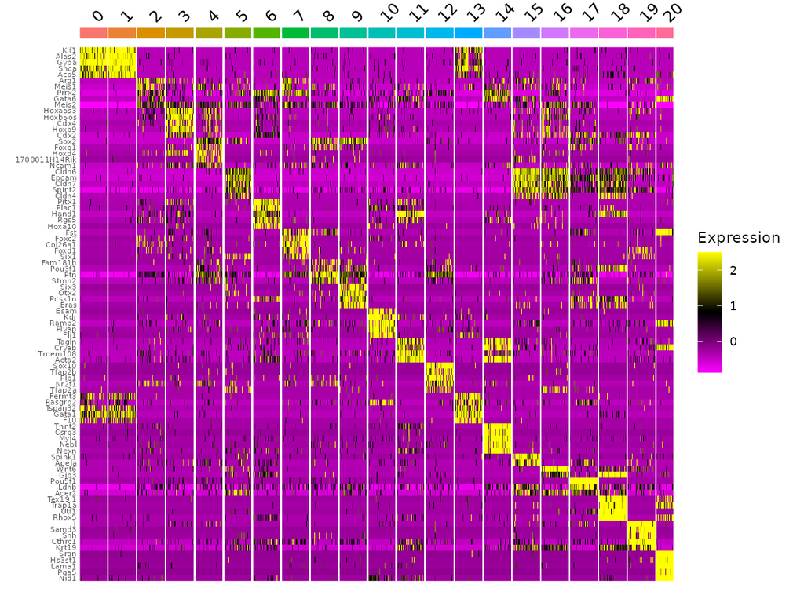

# Manual annotation

## Where to find marker genes

- **Marker databases**
  - [CellMarker 3.0](http://bio-bigdata.hrbmu.edu.cn/CellMarker): curated markers, human and mouse
  - [PanglaoDB](https://panglaodb.se): community-curated markers, human and mouse
- **Atlases and reference data**: CELLxGENE, Allen Brain Cell Atlas
- **Annotation tools**: Azimuth, SingleR, scGate
- **Cell Ontology**: standard names for cell types
- **Literature**: the atlas paper and primary papers for your cell types
- Compare several sources, and confirm with the literature when they disagree

## Check known marker genes

```r
known_markers <- list(
  Epiblast_PS   = c("Pou5f1", "T", "Mesp1"),
  Neural        = c("Sox2", "Sox1", "Otx2", "Six3"),
  Surface_ecto  = c("Krt8", "Krt18", "Tfap2a"),
  Neural_crest  = c("Sox10", "Foxd3"),
  Paraxial_mes  = c("Tbx6", "Meox1", "Pax3"),
  Lateral_mes   = c("Hand1", "Hand2", "Tbx4"),
  Cardiac       = c("Myl7", "Tnnt2", "Nkx2-5"),
  Endothelium   = c("Pecam1", "Cdh5", "Kdr", "Tal1"),
  Blood         = c("Gata1", "Hba-x", "Runx1"),
  Endoderm_gut  = c("Foxa2", "Sox17", "Cdx2"),
  Notochord     = c("Noto", "Shh"),
  ExE_endoderm  = c("Ttr", "Apoa1")
)

# drop markers that are not in the data
known_markers <- lapply(known_markers, intersect, rownames(seu))
```

## DotPlot of the known markers

```r
names(known_markers) <- gsub("_", "\n", names(known_markers))   # "Endoderm_gut" -> "Endoderm\ngut"

DotPlot(seu, features = known_markers) + RotatedAxis() +
  theme(axis.text.x = element_text(size = 8),
        axis.text.y = element_text(size = 7),
        strip.text  = element_text(size = 7),
        legend.text  = element_text(size = 7),
        legend.title = element_text(size = 7),
        legend.key.size = unit(0.3, "cm"))
```

- Dot size: fraction of cells expressing the gene. Color: average expression
- These are **broad lineage** markers: they suggest a lineage, but will not separate close subtypes

## Dot plot for known marker genes

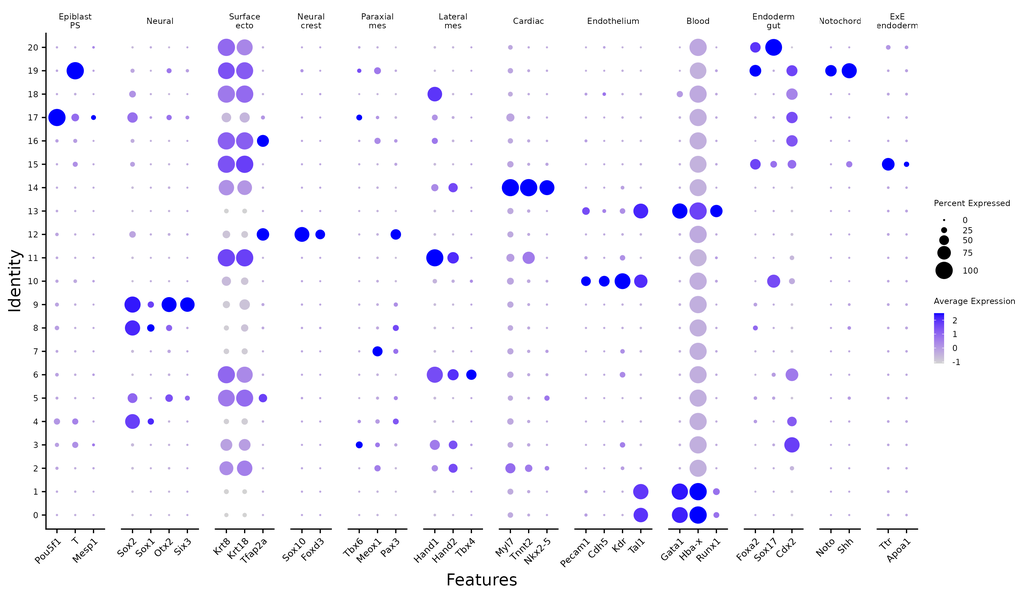

## Compare clusters with the published labels

```r
# Rows = our clusters, columns = published cell types, scaled within each cluster
tab  <- table(Cluster = seu$seurat_clusters, Published = seu$celltype.mapped)
prop <- prop.table(tab, margin = 1)
pheatmap(prop, cluster_rows = FALSE, cluster_cols = FALSE, fontsize = 8)
```

- `table()` counts cells for each cluster and label
- `prop.table(margin = 1)` divides each row by its total, so a row sums to 1

## Reading the cluster vs label heatmap

- A **clean row** (one bright tile): the cluster maps to one label
- A **row with several bright tiles**: a mixed cluster
  - often closely related labels, such as blood progenitors and erythroid cells
- A **label spread over several rows**: a cell type split across clusters

## The most common label per cluster

```r
data.frame(
  cluster = rownames(prop),
  majority_published = colnames(prop)[apply(prop, 1, which.max)],
  fraction = round(apply(prop, 1, max), 2)
)
```

- `apply(prop, 1, which.max)`: for each row, the position of the largest value
- `fraction`: how much of the cluster carries that label

# Reference-based annotation

## SingleR

- Labels **each cell independently**, without using the clusters
  1. finds marker genes for each cell type in the reference
  2. correlates every query cell with each cell type in the reference using those marker genes
  3. picks the best-scoring type
- Cells without a clear winner are flagged as low confidence (`NA` in `pruned.labels`)
- It can only assign labels that exist in the reference

## Load the reference and run SingleR

```r
ref <- readRDS("/varidata/researchtemp/hpctmp/single_cell_workshop_2026/day3/data/ref_EmbryoAtlas_200cells.rds")

dim(ref)
table(ref$celltype)

query_data <- GetAssayData(seu, assay = "RNA", layer = "data")   # log-normalized

pred <- SingleR(test = query_data,  # test is expression matrix like project
                ref = ref,
                labels = ref$celltype,
                de.method = "wilcox",
                aggr.ref = T)

seu$SingleR        <- pred$labels
seu$SingleR_pruned <- pred$pruned.labels      # NA = low-confidence call

sum(is.na(seu$SingleR_pruned)) ## see how many cells got NA.
```

## How well do the labels agree?

```r
# fraction of cells with exactly the same label
mean(seu$SingleR == seu$celltype.mapped, na.rm = TRUE)

# Any difference in cell types between published data and cell types in the reference?
setdiff(unique(seu$celltype.mapped), unique(seu$SingleR))
```

## Agreement is not validation

**Warning**

`celltype.mapped` was itself obtained by mapping onto the atlas, and SingleR uses the atlas as a reference, so the two annotations are **not independent**.

- Agreement shows that SingleR reproduces the published mapping, not that either label is correct
- A small reference (200 cells) can lower agreement, so treat the numbers as a demonstration
- Marker genes (the DotPlot) are the independent check
- Disagreement can be informative: it may highlight cells transitioning between cell states or types, or cells that are poorly represented in the reference

## Clusters vs labels as a proportion heatmap

```r
source("/varidata/researchtemp/hpctmp/single_cell_workshop_2026/day3/scripts/make_annotation_heatmap.R")   # helper function, see the appendix

res1 <- make_annotation_heatmap(seu, annotation_col = "celltype.mapped",
                                title = "Clusters vs published labels",
                                exclude = c("Doublet", "Stripped"))

res2 <- make_annotation_heatmap(seu, annotation_col = "SingleR",
                                title = "Clusters vs SingleR")

res1$plot + res2$plot
```

- Each tile is the fraction of a cluster’s cells carrying a label
- Annotations are ordered so clean clusters form a diagonal

# Wrap-up

## Discussion

- Which clusters mapped cleanly to one label, and which were mixed?
- Where did the published and SingleR labels disagree?
- Why is a cluster with two related labels not necessarily a failure?

## Take-home

- Markers rank genes for a cluster: use `pct.1`, `pct.2`, and `avg_log2FC` together
- Visualize with several plots: each shows something different
- Annotate with markers first, then check with a reference
- Compare cluster-level and cell-level labels, and treat disagreement as information